# cox_subgroup_forest() Tutorial

## 3.1 Specify x-axis

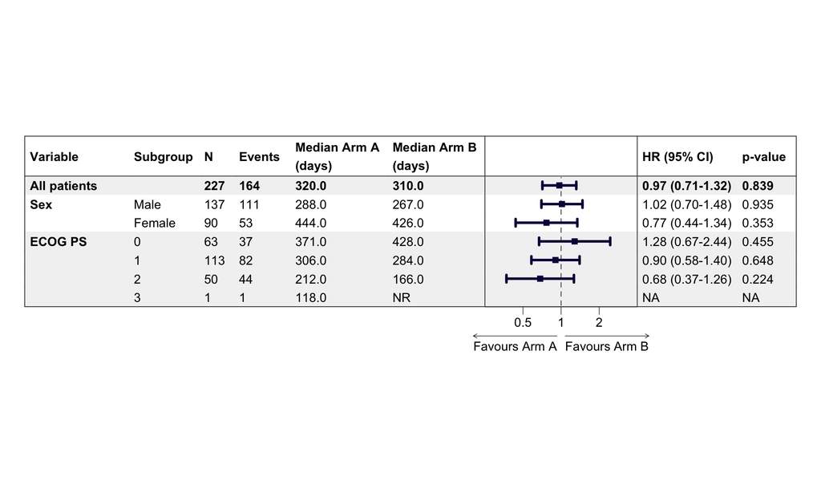

```r
res_x <- cox_subgroup_forest(
  data = lung2,
  covariates = c("sex", "ph.ecog"),
  labels     = c("Sex", "ECOG PS"),
  treatment = "treatment",
  time = c("time_os"),
  event = c("event_os"),
  endpoint_labels = c("Overall Survival"),
  time_unit = "days",
  palette = c("#0F084B"),
  xlim = c(0.25, 4),
  ticks_at = c(0.5, 1, 2)
)

res_x$combined_plots
```

# 4 Excluding a level

`ph.ecog == "3"` has only a handful of patients in `lung`. `exclude_levels` drops it by setting those values to `NA`, which then falls out through the existing complete-case filtering used inside each model:

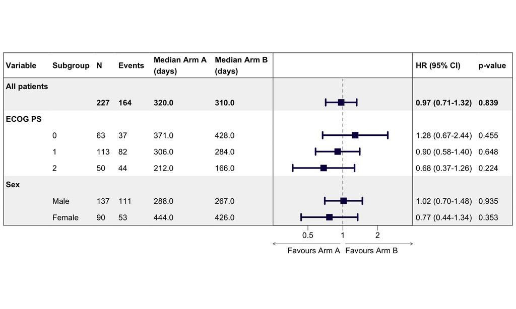

```r
res_excl <- cox_subgroup_forest(
  data = lung2,
  covariates = c("sex", "ph.ecog"),
  labels = c("Sex", "ECOG PS"),
  treatment = "treatment",
  time = c("time_os"),
  event = c("event_os"),
  endpoint_labels = c("Overall Survival"),
  time_unit = "days",
  palette = c("#0F084B"),
  exclude_levels = list(ph.ecog = "3"),
  xlim = c(0.25, 4),
  ticks_at = c(0.5, 1, 2),
  length_plot = 60,
  #weights = "weights_ATE", # optional if PS used
  ci_pch = 15,
  ci_lty = 1,
  ci_lwd = 3,
  ci_Theight = 0.4,
  sizes = 1,
  row_height = 1.4,
  covariate_label_row = TRUE
)

res_excl$combined_plots
```

# 5 Multiple endpoints (OS and PFS) with colour coding

Pass `time` and `event` as vectors, paired by position, along with matching `endpoint_labels`. With more than one endpoint the plot automatically colour-codes the confidence intervals per endpoint and adds a legend below the figure.

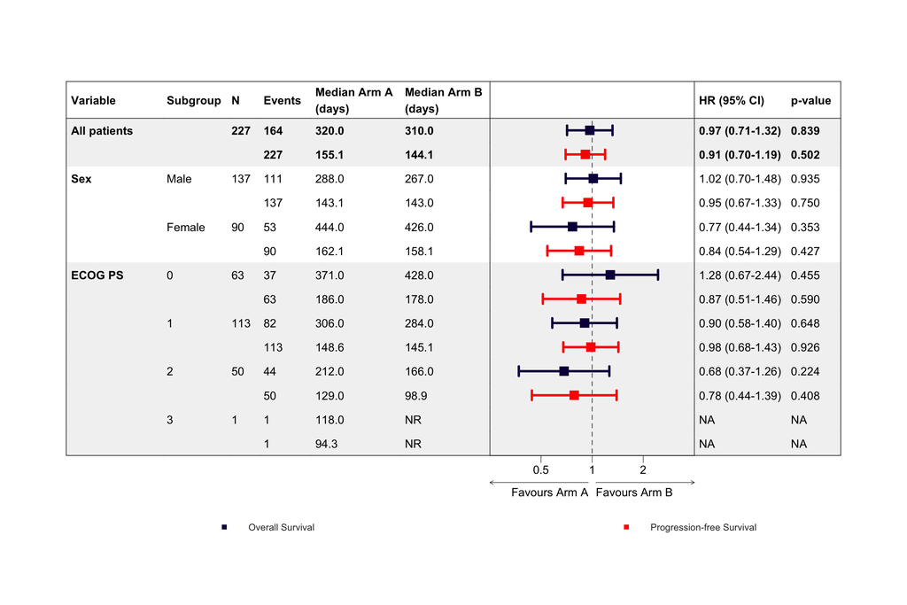

```r
res_two_ep <- cox_subgroup_forest(
  data = lung2,
  covariates = c("sex", "ph.ecog"),
  labels = c("Sex", "ECOG PS"),
  treatment = "treatment",
  time = c("time_os", "time_pfs"),
  event = c("event_os", "event_pfs"),
  endpoint_labels = c("Overall Survival", "Progression-free Survival"),
  time_unit = "days",
  palette = c("#0F084B", "red"),
  #exclude_levels = list(ph.ecog = "3"),
  xlim = c(0.25, 4),
  ticks_at = c(0.5, 1, 2),
  length_plot = 60,
  #weights = "weights_ATE", # optional if PS used
  ci_pch = 15,
  ci_lty = 1,
  ci_lwd = 3,
  ci_Theight = 0.4,
  sizes = 1,
  row_height = 1.4
)

res_two_ep$combined_plots
```

# 6 Styling the plot

A few of the most commonly adjusted arguments:

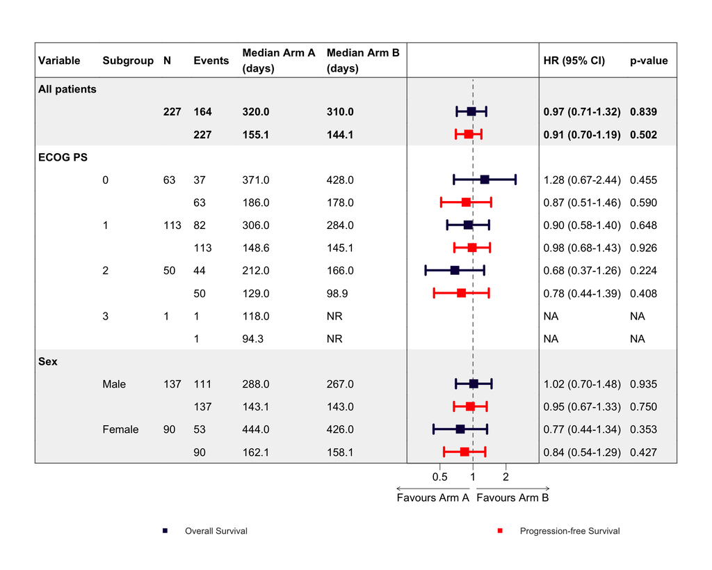

```r
res_styled <- cox_subgroup_forest(
  data = lung2,
  covariates = c("sex", "ph.ecog"),
  labels = c("Sex", "ECOG PS"),
  treatment = "treatment",
  time = c("time_os", "time_pfs"),
  event = c("event_os", "event_pfs"),
  endpoint_labels = c("Overall Survival", "Progression-free Survival"),
  time_unit = "days",
  palette = c("#0F084B", "red"),
  #exclude_levels = list(ph.ecog = "3"),
  xlim = c(0.25, 4),
  ticks_at = c(0.5, 1, 2),
  #weights = "weights_ATE", # optional if PS used
  ci_pch = 15,
  ci_lty = 1,
  ci_lwd = 3,
  ci_Theight = 0.4,
  sizes = 1,
  row_height = 1.4,
  covariate_label_row = TRUE
)


res_styled$combined_plots
```

- `row_height` — multiplier applied to every body row’s height (`1.4` = 40% taller); useful when labels wrap or the figure feels cramped.
- `covariate_label_row = TRUE` inserts a dedicated bold row with just the covariate name above its levels, instead of bolding the first level row in place.
- `xlim` / `ticks_at` let you fix the axis range and tick marks manually instead of relying on the automatic (CI-range-based) defaults — handy for keeping several related figures on the same scale.

# 7 Adopt length of the forestplot

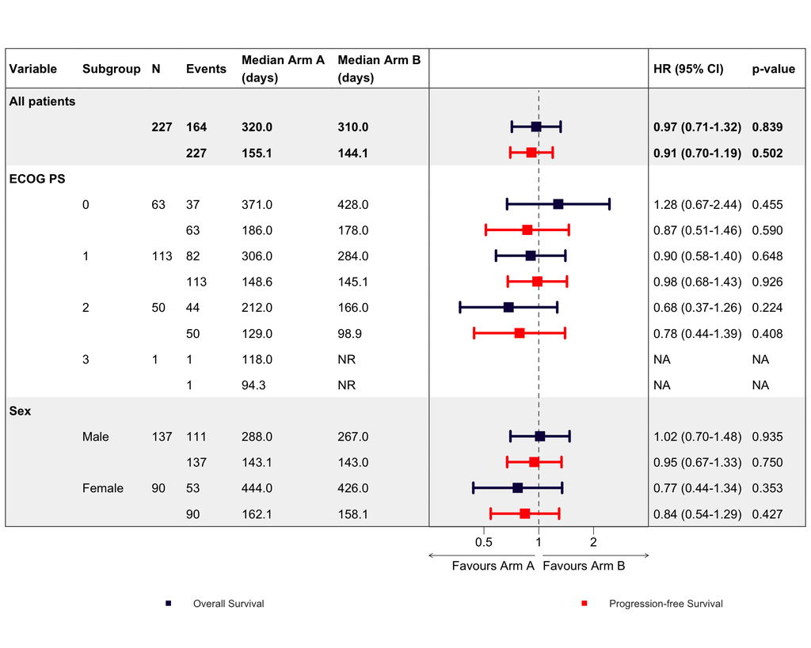

```r
res_length <- cox_subgroup_forest(
  data = lung2,
  covariates = c("sex", "ph.ecog"),
  labels = c("Sex", "ECOG PS"),
  treatment = "treatment",
  time = c("time_os", "time_pfs"),
  event = c("event_os", "event_pfs"),
  endpoint_labels = c("Overall Survival", "Progression-free Survival"),
  time_unit = "days",
  palette = c("#0F084B", "red"),
  #exclude_levels = list(ph.ecog = "3"),
  xlim = c(0.25, 4),
  ticks_at = c(0.5, 1, 2),
  #weights = "weights_ATE", # optional if PS used
  length_plot = 60,
  ci_pch = 15,
  ci_lty = 1,
  ci_lwd = 3,
  ci_Theight = 0.4,
  sizes = 1,
  row_height = 1.4,
  covariate_label_row = TRUE
)
res_length$combined_plots
```